title: “Bilgi Yönetim Sistemleri - Bitirme Projesi Rapor : İsmet Koçer 190401010,Uğur Öztürk,Ahmet Akkoç,Gamze Kocaman.” output: html_document date: “2024-05-23”

## Q1 : İş probleminin tanımı

Biz, firmaların satış verilerini kullanarak kârlarını artırma amaçlı yöntemler uyguluyoruz ve sonuçları tahmin şeklinde sunuyoruz. Bu süreçte, **Metabase** adlı BYS platformunu kullanıyoruz. Metabase’i tercih etme nedenimiz, gelişmiş görselleştirme yöntemlerine sahip olmasıdır. Bu süreçte, *SQL Server* bağlantı ve verileri görselleştirebilme özelliklerinden yararlanacağız.

## Q2 : İş problemini çözmede kullanılacak data seti

Veri setimizi Kaggle’den elde ettik.

Hindistan’dan bir e-ticaret satış veri setimiz var ve toplam 88.23 kB boyutunda 2 CSV dosyasını içeriyor: List of Orders, Order Details. Hintli bir öğrencinin üniversitesinden aldığı veri kümesi olup, orijinal yazarı bilinmiyor.

İçeriği:

List of Orders: Bu veri seti, satın alma bilgilerini içerir. Bilgiler arasında Satın Alma Kimliği, Satın Alma Tarihi ve müşteri detayları bulunur. Order Details: Bu veri seti, sipariş kimliği, sipariş fiyatı, miktarı, karı, ürün kategorisi ve alt kategorisi ile birlikte sipariş bilgilerini içerir.

## Q3 : Veri seti keşifsel anazalizi

Veri setimizin önemli sütunları: OrderID, Amount, Profit, Quantity. OrderID veri tipi string, geri kalanlar float veri tipindedir. List of orders tablosunda boş satırlar mevcuttur. Bu satırların temizlenmesi gerekmektedir. Tablonun sonunda 60 satır boş veri bulunmaktadır. Tablonun genelinde tekrar eden böyle bir durum yoktur.

#### Boş satırların silinmiş hali

```r
temizlenmis_tablo
```

```
##     Order ID Order Date CustomerName             State               City
## 1    B-25601 01-04-2018       Bharat           Gujarat          Ahmedabad
## 2    B-25602 01-04-2018        Pearl       Maharashtra               Pune
## 3    B-25603 03-04-2018        Jahan    Madhya Pradesh             Bhopal
## 4    B-25604 03-04-2018       Divsha         Rajasthan             Jaipur
## 5    B-25605 05-04-2018      Kasheen       West Bengal            Kolkata
## 6    B-25606 06-04-2018        Hazel         Karnataka          Bangalore
## 7    B-25607 06-04-2018     Sonakshi Jammu and Kashmir            Kashmir
## 8    B-25608 08-04-2018      Aarushi        Tamil Nadu            Chennai
## 9    B-25609 09-04-2018       Jitesh     Uttar Pradesh            Lucknow
## 10   B-25610 09-04-2018       Yogesh             Bihar              Patna
## 11   B-25611 11-04-2018        Anita           Kerala  Thiruvananthapuram
## 12   B-25612 12-04-2018    Shrichand            Punjab         Chandigarh
## 13   B-25613 12-04-2018       Mukesh           Haryana         Chandigarh
## 14   B-25614 13-04-2018      Vandana  Himachal Pradesh              Simla
```

[output cut: 486 more lines]

### Sub-Category başına toplam kâr-zararı buluyoruz.

```r
gruplanmis_profit
```

```
## # A tibble: 17 × 2
##    `Sub-Category`   Toplam_Profit
##    <chr>                    <dbl>
##  1 Accessories             355900
##  2 Bookcases               488800
##  3 Chairs                   57700
##  4 Electronic Games       -123600
##  5 Furnishings              84400
##  6 Hankerchief             209800
##  7 Kurti                    18100
##  8 Leggings                 26000
##  9 Phones                  220700
## 10 Printers                596400
## 11 Saree                    35200
## 12 Shirt                   113100
## 13 Skirt                    23500
## 14 Stole                   255900
## 15 T-shirt                 150000
## 16 Tables                 -401100
## 17 Trousers                284700
```

### Üstteki tablonun Metabase’de oluşturulan grafiğinin gösterimi(Kâr-zarar tablosu)

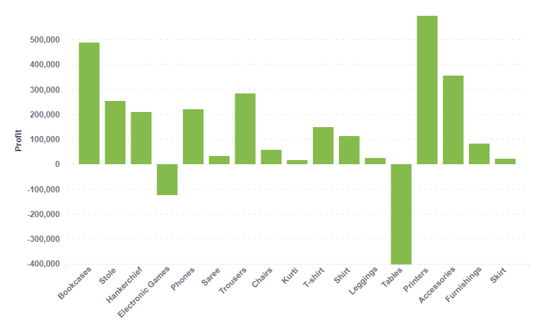

### Zarar eden satışların oranı

```
## [1] 0.3353333
```

### Şirketin toplam kârı

```
## [1] 2395500
```

## Q4: Veri setinin BYS platformuna ithali

Kullandığımız BYS platformu Metabase. Metabase’e veri aktarabilmek için bir veritabanı bağlamamız gerekiyordu. Bu yüzden Docker’a bir SQL Server konteynırı kurduk. Bu SQL Server’a veri setimizi yükledik. Metabase’den veri tabanımızın bağlantı bilgilerini kullanarak bağlantı sağlayarak BYS platformumuza veri setimizi ithal etmiş olduk.

## Q5: Yapılması planlanan veri analizi

Öncelikle yapmamız gereken Sub-Category başına kâr-zarar bilgilerine ulaşmak ve bunu sunmaktı. Elimizde bir çok bilgi olmasına rağmen ilk ilgilenmemiz taraf burası. Bunun nedeni bir satıştan zarar etmiş olmak, genelde zarar edeceğiniz anlamına gelmiyor. Lokasyon olarak bazı ürünlerden yüksek, bazı ürünlerden düşük kâr etmelisiniz. Hatta yeri geldiğinde küçük zararları bile kabul etmelisiniz. Bu yüzden bize genel bir yorum lazımdı. Lokasyon analizi yapabilmek adına Sub-Category başına elde ettiğimiz tablonun kaynağını yani orderdetails tablosunu listoforders tablosuyla Order ID sütununu kullanarak joinleyeceğiz. listoforders tablosundan sadece City bilgisi, orderdetails tablosundan ise Amount,Profit,Quantity,Sub-Category sütunlarını alacağız. Daha sonra sub-category ve City için gruplayıp Profit sütununu toplatacağız. Bu tablo şirketi değil bizi ilgilendiren tablo olucak. Lokasyon başına toplam kârı çok azsa veya zarardaysa bu lokasyona bir aksiyon almamız gerektiğini anlayacağız. Bu aksiyonlar indirimle satış adedini arttırmak, zaten satışı yüksekse kâr yapmak gibi yöntemler olabilir.

## Q6 : Çalışan platformun gösterildiği sesli anlatımlı video

https://youtu.be/l6SWaeMexD8

# Final

## İşlemlerimiz sonrası şirketin tahmini satış verileri

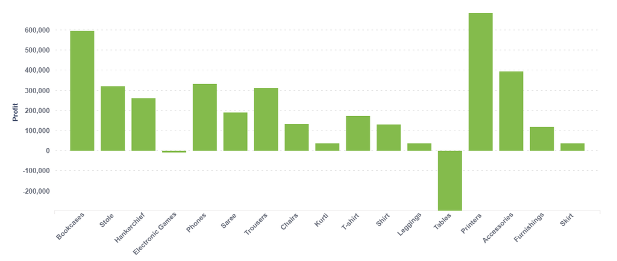

### İşlemler sonrası Sub-Category başına beklenen kâr-zararı buluyoruz.

```r
gruplanmis_profit2
```

```
## # A tibble: 17 × 2
##    `Sub-Category`   Toplam_Profit
##    <chr>                    <dbl>
##  1 Accessories             394725
##  2 Bookcases               596340
##  3 Chairs                  133315
##  4 Electronic Games         -8066
##  5 Furnishings             121227
##  6 Hankerchief             262907
##  7 Kurti                    36329
##  8 Leggings                 38668
##  9 Phones                  331614
## 10 Printers                685335
## 11 Saree                   192323
## 12 Shirt                   132101
## 13 Skirt                    36197
## 14 Stole                   321137
## 15 T-shirt                 174087
## 16 Tables                 -297360
## 17 Trousers                314197
```

### Şirketin işlemlerimiz sonrası beklenen toplam kârı

```
## [1] 3465076
```

Yapılan işlemler sonrası şirkette beklenen kâr oranlarındaki değişim yukarıda gösterilmiştir.